# RMarkdown_Project

Akarin Luckanasub

2024-05-27

## **Exploring and Visualizing Data**

### **Data: Fuel economy data from 1999 to 2008 for 38 popular models of cars(mpg)**

```
## # A tibble: 6 × 11
##   manufacturer model displ  year   cyl trans      drv     cty   hwy fl    class
##   <chr>        <chr> <dbl> <int> <int> <chr>      <chr> <int> <int> <chr> <chr>
## 1 audi         a4      1.8  1999     4 auto(l5)   f        18    29 p     compa…
## 2 audi         a4      1.8  1999     4 manual(m5) f        21    29 p     compa…
## 3 audi         a4      2    2008     4 manual(m6) f        20    31 p     compa…
## 4 audi         a4      2    2008     4 auto(av)   f        21    30 p     compa…
## 5 audi         a4      2.8  1999     6 auto(l5)   f        16    26 p     compa…
## 6 audi         a4      2.8  1999     6 manual(m5) f        18    26 p     compa…
```

#### **The correlation between highway MPG and city MPG for different car models**

##### This scatter plot provides a visual representation of the correlation between highway MPG and city MPG for different car models, with each model distinguished by color. It allows for easy identification of trends, variations, and outliers, facilitating comparisons across different car models. This plot can help understand how fuel efficiency in urban settings correlates with fuel efficiency on highways and how this relationship varies among different car models.

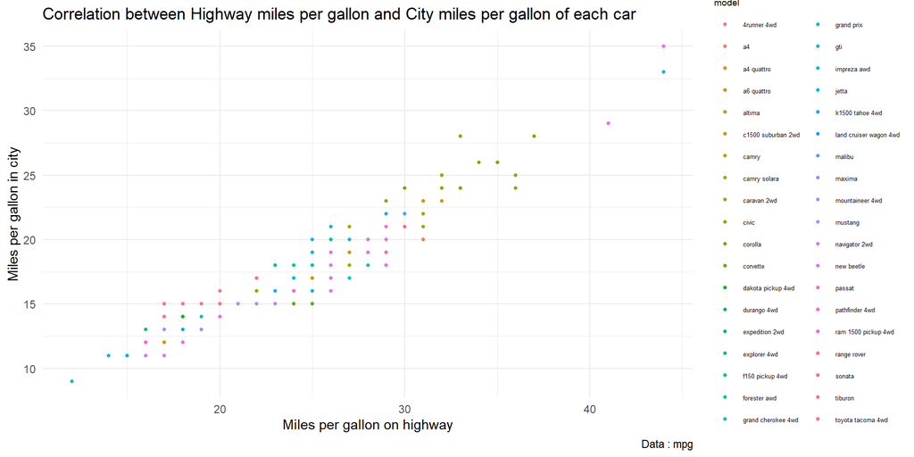

#### **Engine Displacement vs. Highway MPG**

##### This scatter plot provides a visual representation of the relationship between engine displacement and highway MPG, with car classes distinguished by color. It allows for easy identification of trends, variations, and outliers, facilitating comparisons across different car classes. This plot can help understand how engine size impacts fuel efficiency and how this relationship varies among different types of cars.

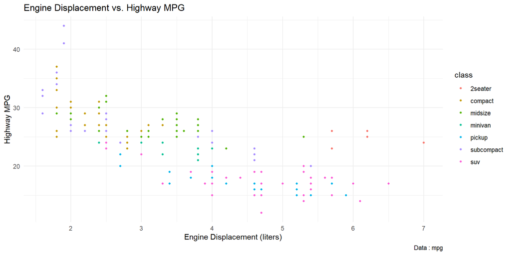

#### **Boxplot of highway MPG by car class**

##### This boxplot provides a clear and concise visual summary of how highway MPG varies by car class. It highlights differences in central tendency (median), dispersion (IQR), and the presence of outliers, enabling easy comparisons across car classes.

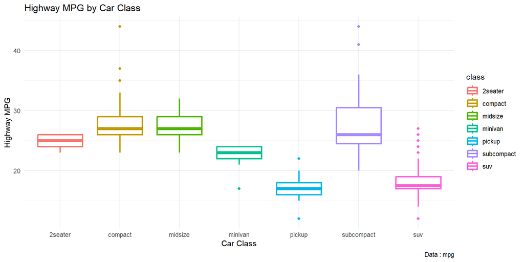

#### **Bar plot of the count of car models by manufacturer**

##### This bar plot provides a visual summary of the count of car models for each manufacturer in the mpg dataset. It allows for easy comparison of the number of models between different manufacturers. The use of color coding and axis text adjustment improves readability, especially when dealing with a large number of manufacturers. This plot can help understand the distribution of car models among various manufacturers and identify which manufacturers have more or fewer models represented in the dataset.

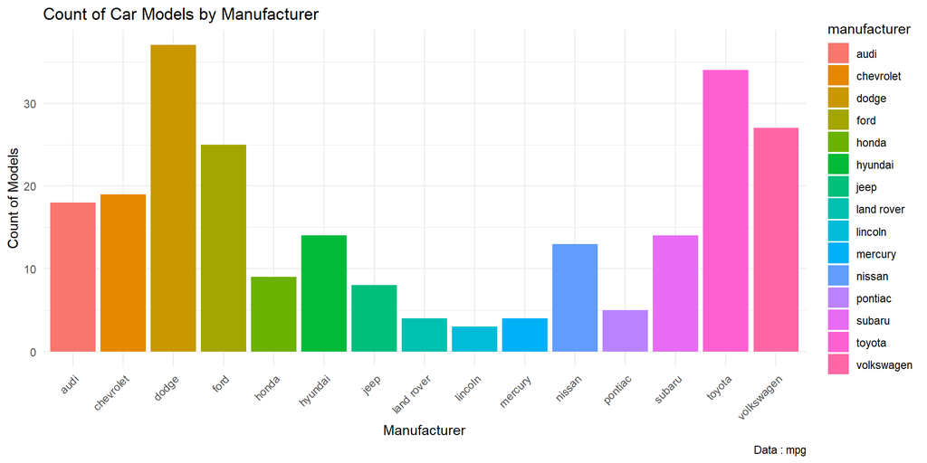

#### **Faceted scatter plot of engine displacement vs. highway MPG by year**

##### This faceted scatter plot provides a visual representation of the relationship between engine displacement and highway MPG for different years, with points colored by engine displacement. It allows for easy identification of trends, variations, and outliers within each year and facilitates comparisons across different years. This plot can help understand how the relationship between engine size and fuel efficiency on highways evolves over time.

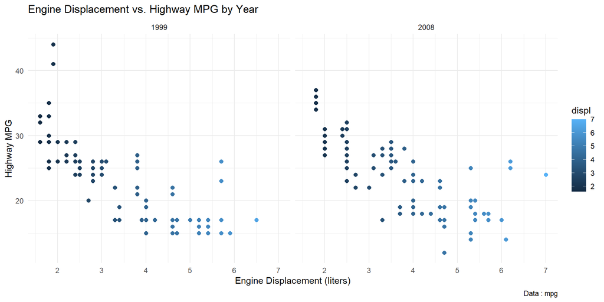

—